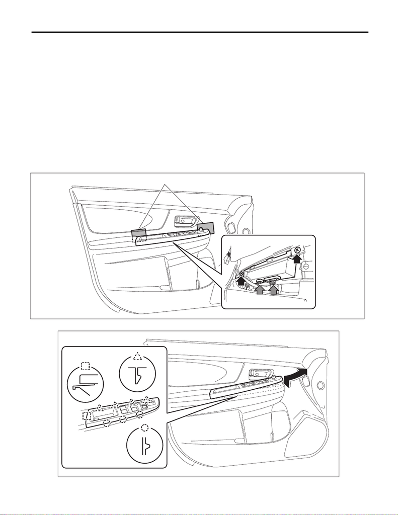

GW-11

Power Window Control Switch

GLASS/WINDOWS/MIRRORS

4. Power Window Control Switch

A: REMOVAL

1. MAIN SWITCH

1) Disconnect the ground cable from battery and wait for at least 60 seconds before starting work. <Ref. to

NT-5, BATTERY, NOTE, Note.>

NOTE:

For models other than STI model, disconnect the ground terminal from battery sensor.

2) Remove the trim panel - front door. <Ref. to EI-56, FRONT DOOR, REMOVAL, Door Trim.>

3) Remove the panel - power window main switch.

CAUTION:

Be careful not to damage the trim panel - front door with the panel - power window main switch.

(1) Insert a sheet of protective paper (a) between panel - power window main switch and trim panel - front

door.

(2) Remove the screws and disconnect the connector.

(3) Release the claws, and then remove the panel - power window main switch.

GW-01413

(a)

GW-01020

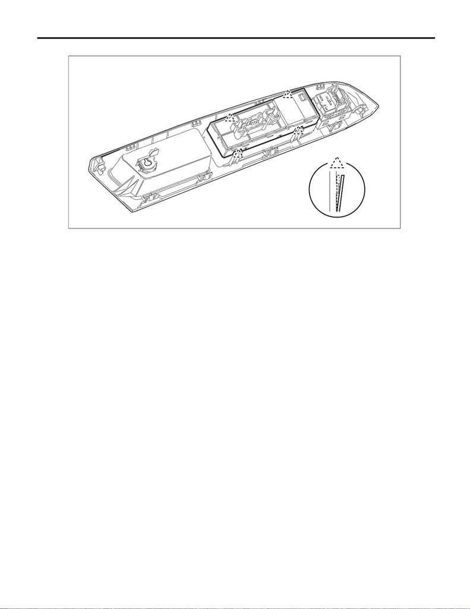

GW-12

Power Window Control Switch

GLASS/WINDOWS/MIRRORS

(4) Release the claws, and then remove the switch - power window main.

2. SUB-SWITCH

Switch - power window sub front

For removal of the switch - power window sub front on the passenger’s seat, refer to the removal procedure

of the switch - power window main. <Ref. to GW-11, MAIN SWITCH, REMOVAL, Power Window Control

Switch.>

Switch - power window sub rear

1) Disconnect the ground cable from battery. <Ref. to NT-5, BATTERY, NOTE, Note.>

NOTE:

For models other than STI model, disconnect the ground terminal from battery sensor.

2) Remove the trim panel - rear door. <Ref. to EI-57, REAR DOOR, REMOVAL, Door Trim.>

3) Remove the panel - power window sub switch rear.

CAUTION:

Be careful not to damage the trim panel - rear door with the panel - power window sub switch rear.

(1) Insert a sheet of protective paper (a) between panel - power window sub switch rear and trim panel -

rear door.

GW-01414

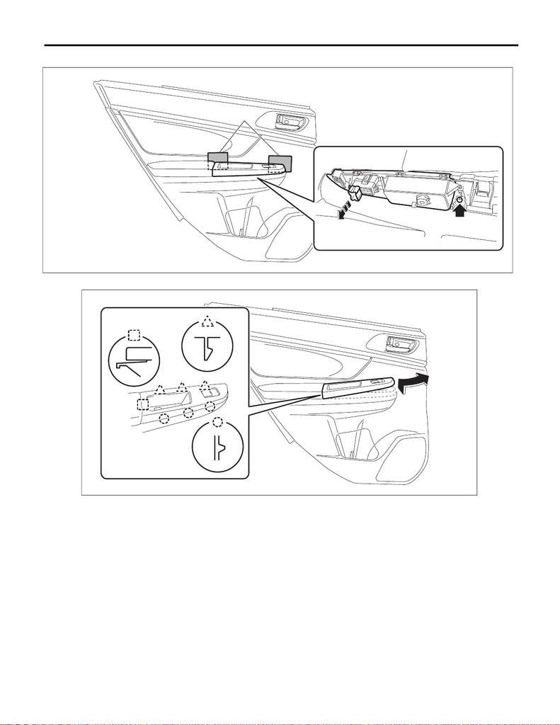

GW-13

Power Window Control Switch

GLASS/WINDOWS/MIRRORS

(2) Remove the screws and disconnect the connector.

(3) Release the claws, and then remove the panel - power window sub switch rear.

GW-01382

(a)

GW-01023

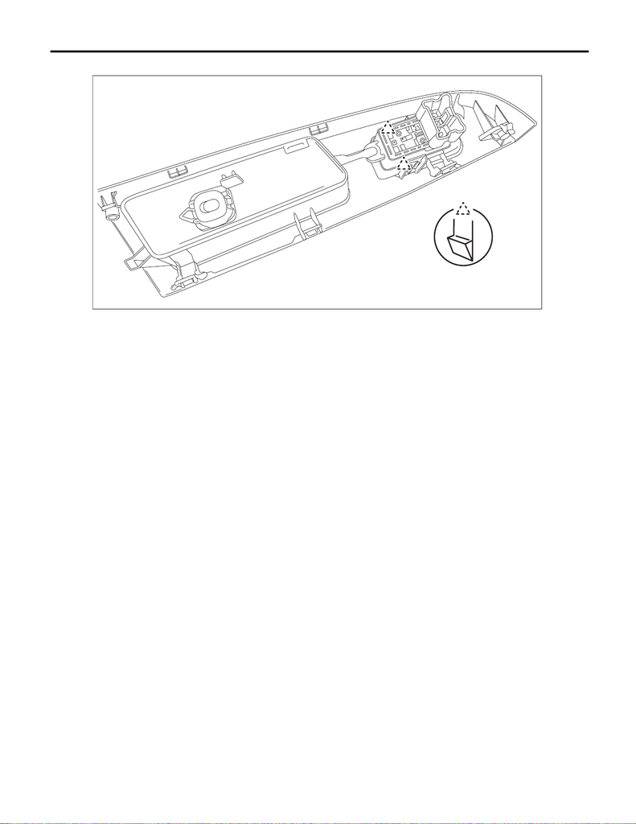

GW-14

Power Window Control Switch

GLASS/WINDOWS/MIRRORS

4) Release the claws, and then remove the switch - power window sub rear.

B: INSTALLATION

1. MAIN SWITCH

CAUTION:

• After installing the switch - power window main, always perform the initial setting.

Failure to do so may cause the improper activation of auto-reverse operation for pinching hazard pre-

vention.

• Use protective paper to avoid damage to the trim panel.

1) Install the panel - power window main switch to the trim panel - front door.

2) Install the trim panel - front door. <Ref. to EI-58, INSTALLATION, Door Trim.>

3) Connect the battery ground terminal. <Ref. to NT-5, BATTERY, NOTE, Note.>

NOTE:

For models other than STI model, connect the ground terminal to battery sensor.

4) Perform initial setting operation (reset operation A). <Ref. to GW-9, RESET OPERATION A, OPERA-

TION, Power Window System.>

2. SUB-SWITCH

CAUTION:

Use protective paper to avoid damage to the trim panel.

Switch - power window sub front

For installation of the switch - power window sub front on the passenger’s seat, refer to the installation pro-

cedure of the switch - power window main. <Ref. to GW-14, MAIN SWITCH, INSTALLATION, Power Win-

dow Control Switch.>

Switch - power window sub rear

1) Install the panel - power window sub switch rear to the trim panel - rear door.

2) Install the trim panel - rear door. <Ref. to EI-58, INSTALLATION, Door Trim.>

3) Connect the battery ground terminal. <Ref. to NT-5, BATTERY, NOTE, Note.>

NOTE:

For models other than STI model, connect the ground terminal to battery sensor.

GW-01390

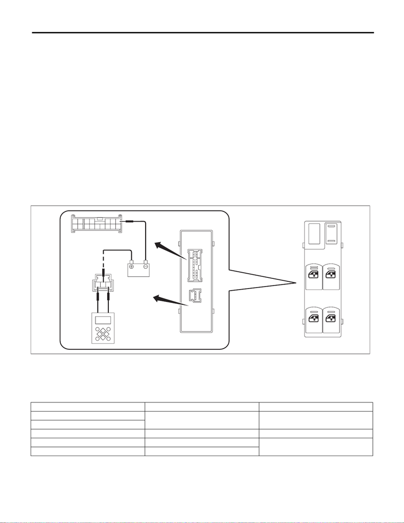

GW-15

Power Window Control Switch

GLASS/WINDOWS/MIRRORS

C: INSPECTION

1. MAIN SWITCH

• Driver’s seat

CAUTION:

Since the switch - power window main is controlled by CPU, do not check continuity for switch alone

with the circuit tester. Performing continuity check with circuit tester can damage the switch - power

window main circuit.

Check output from the switch - power window main to the driver’s side motor using the oscilloscope function

in the Subaru Select Monitor.

1) Remove the switch - power window main.

2) Connect the battery and the Subaru Select Monitor to the switch - power window main terminal.

CAUTION:

Never mix up the terminals when connecting the harness connector of the switch - power window

main and the battery. If the connection is wrong, the switch - power window main may be damaged.

NOTE:

• When the battery is connected to the switch - power window main terminal, the letters “AUTO” on the driv-

er’s side knob illuminates.

• For detailed procedures, refer to “Subaru Select Monitor Operation Manual”.

3) Operate the switch - power window main and check the output.

NOTE:

Since output time during window UP operation is extremely short, it cannot be checked without using a mea-

suring instrument such as oscilloscope. Output is constantly produced while the switch is operated for win-

dow DOWN operation.

4) If the inspection result is not within the standard, replace the switch - power window main.

Inspection conditions Output time Standard

AUTO UP

Approx. 130 ms Battery voltage

UP

OFF — 0 V

DOWN During switch operation

Battery voltage

AUTO DOWN Approx. 300 ms

GW-01415

1

23

8

10

4

567

9

AUTO

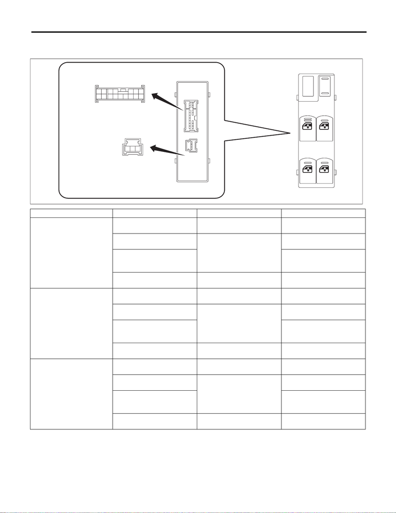

GW-16

Power Window Control Switch

GLASS/WINDOWS/MIRRORS

• Except for driver’s seat

1) Check the resistance between terminals of the switch - power window main.

2) If the inspection result is not within the standard, replace the switch - power window main.

Terminal No. Inspection conditions Standard

Passenger’s seat

14 — 8

2 — 1

UP Less than 1 Ω

14 — 2

14 — 8

OFF

1 MΩ or more

1 — 2

1 — 8

2 — 8

Less than 1 Ω

14 — 2

1 — 8

DOWN Less than 1 Ω

Rear LH

14 — 15

1 — 16

UP Less than 1 Ω

14 — 15

14 — 16

OFF

1 MΩ or more

1 — 15

1 — 16

15 — 16

Less than 1 Ω

14 — 16

1 — 15

DOWN Less than 1 Ω

Rear RH

14 — 7

1 — 6

UP Less than 1 Ω

14 — 6

14 — 7

OFF

1 MΩ or more

1 — 6

1 — 7

6 — 7

Less than 1 Ω

14 — 6

7 — 1

DOWN Less than 1 Ω

GW-01432

1

23

8

10

4

567

9

AUTO

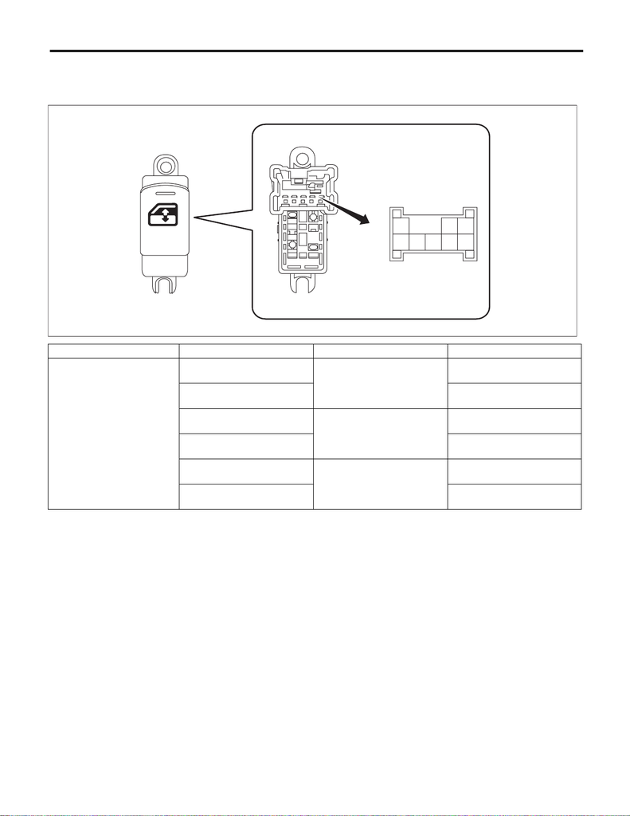

GW-17

Power Window Control Switch

GLASS/WINDOWS/MIRRORS

2. SUB-SWITCH

1) Remove the switch - power window sub.

2) Check the resistance between terminals of the switch - power window sub.

Terminal No. Inspection conditions Standard

Passenger seat, rear

4 — 5

7 — 8

OFF

Less than 1 Ω

5 — 6

6 — 8

1 MΩ or more

5 — 6

7 — 8

UP

Less than 1 Ω

4 — 5

4 — 8

1 MΩ or more

4 — 5

6 — 8

DOWN

Less than 1 Ω

4 — 6

7 — 8

1 MΩ or more

GW-01430

123

4567

8

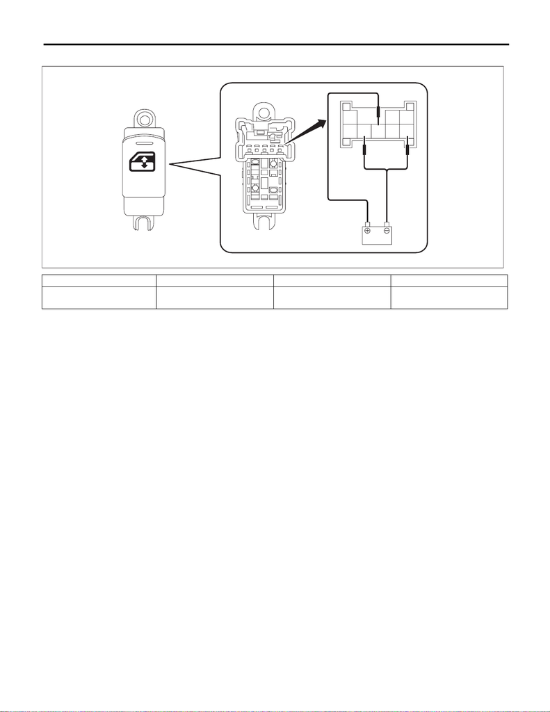

GW-18

Power Window Control Switch

GLASS/WINDOWS/MIRRORS

3) Check the switch light illumination condition.

4) If the inspection result is not within the standard, replace the switch - power window sub.

Terminal No. Inspection conditions Specification

Passenger seat, rear 6 — 7, 4

Battery connection between

terminals

Light ON

GW-01431

123

4567

8